DESIGN BLUEPRINT · ILLUSTRATIVE FIGURES · NO VERSION 2 OUTCOMES FITTED

# Herring × eBird Version 2

A comprehensive multi-model plan to use the full value of eBird complete checklists and Pacific herring spawn records: occurrence, flock size, timing, distance, redistribution, guild response, community composition, co-occurrence, phenological tracking, event heterogeneity, and observation-process bias.

58 canonical species rows8 canonical guilds45 registered models50 comprehensive analysis modulesFixed synthetic-figure seed 1988

## How to read this plan

**All example figures are synthetic.** They demonstrate the intended output and interpretation. They are not empirical Version 2 results and must never be presented as such.

**Lay summary**This project will not rely on one model or one p-value. It will ask several different questions—how many birds, which species, when, how close, whether birds move from elsewhere, and whether species gather together—and then look for agreement across those answers.

The plan distinguishes estimands rather than treating every model as a substitute for every other model. Encounter probability, positive flock size, zero-inclusive reported count, regional allocation, richness, community composition, and residual species association are different response processes and will be reported separately. Cross-model synthesis will combine direction, magnitude, uncertainty, predictive performance, and placebo evidence without averaging incompatible scales.

## Executive strategy

Version 2 should widen the biological question while keeping the strongest parts of Version 1: complete checklists, explicit effort, zero-filling, event-level herring exposure, reproducible processing, privacy controls, and honest interpretation boundaries.

2-part

Primary count architecture

### Occurrence + flock size

Model detection and positive reported count separately, then compare with a zero-inclusive count benchmark.

Space × time

Primary exposure architecture

### Rings, decay, trajectories

Use event-day bins, continuous trajectories, concentric rings, and supported time-distance surfaces.

Near ↔ far

Primary redistribution architecture

### Allocation and mass balance

Estimate whether birds concentrate near spawn while farther shorelines lose share.

Species → guild

Biological hierarchy

### Mechanisms with heterogeneity

Retain species-specific results, then synthesize by feeding mechanism and region.

Community

Multispecies architecture

### Richness, composition, co-occurrence

Use JSDMs/GLLVMs and null-adjusted networks without claiming residual correlations are direct interactions.

Birds + birders

Observation process

### Visitation beside biology

Model checklist and observer allocation in parallel with biological responses.

Raw EBD + SED

→

Complete checklist universe

→

Species/guild outcomes

→

Event-day-distance exposure

→

Multi-model triangulation

→

Validated evidence dashboard

## Evidence base and lessons from Version 1

**Lay summary**Dedicated herring studies have recorded very large bird gatherings, but the first eBird analysis mostly tested whether a species appeared on a checklist. Version 2 therefore gives much more attention to flock size, total numbers, distance, timing, movement among places, and whole-community change.

The uploaded review describes short-lived, spatially concentrated resource pulses, multispecies flocks, strong aggregative responses by gulls, scoters and Harlequin Ducks, and the need to model eBird effort and observer behavior. It also notes the mismatch between local acute bird response and the herring dataset’s event/location/section hierarchy. The Version 1 repository established a reproducible 2015–2025 same-event encounter analysis, but also documented count signals, calendar separation, preferential-visitation concerns, an unsuccessful rank-one multispecies model, and a failed regional redesign support gate.

[output not shown]

[figure not shown]

Illustrative Figure 1. Annual eBird effort generally grows much faster than the number of herring events. Year, period, and event support therefore require explicit balancing or hierarchical treatment.

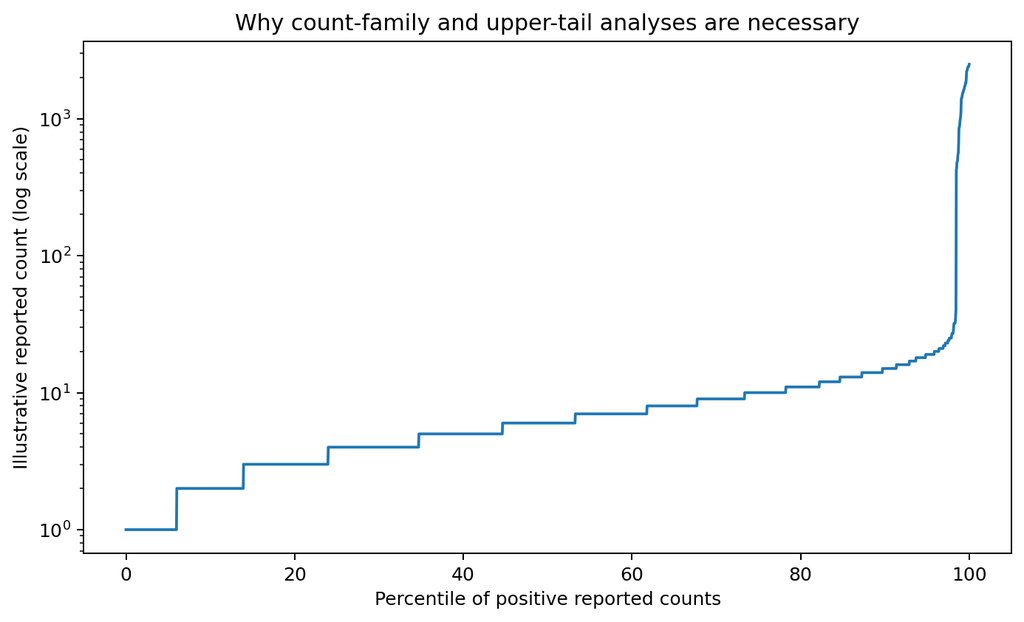

Illustrative Figure 2. Positive bird counts are expected to be highly right-skewed. Ordinary Gaussian averages are inadequate; hurdle, NB/Tweedie, ordinal, influence, and upper-tail analyses are complementary.

## Data assets and metadata extraction

**Lay summary**The value of eBird is not only the bird list. It also records how long people searched, how far they travelled, how many observers participated, and whether the checklist was complete. The herring table contains more than a yes/no spawn flag: timing, position, length, width, survey method, and several components of the spawn index.

| Asset | Role | Scale/version | High-value fields | Main cautions |
| --- | --- | --- | --- | --- |
| eBird EBD | Bird observations | May 2026 BC release; ~14.6 GB in V1 manifest | Taxon, count/X, date, checklist key, behaviour, age/sex, comments | Restricted; never commit raw or row-level derivatives |
| eBird SED | Checklist observation process | Matching May 2026 release; ~758 MB | Protocol, effort, complete flag, observers, start time, locality, coordinates | Collapse shared checklists; model effort and observer behaviour |
| DFO herring table | Spawn events and relative index | 31,167 source rows; 13,332 post-1988 in V1 audit | Dates, location, section, length, width, method, Surface/Macrocystis/Understory | Relative index, incomplete components, date/geometry uncertainty |
| DFO sections | Spatial hierarchy | 95 post-1988 sections represented in V1 field summary | Assessment region, statistical area, section polygons | Boundary/stratification/QA; not automatically the exposure unit |
| BC coastline | Shoreline linkage | Metric shoreline layer in BC Albers | Coastline segments and source class | Checklist points and herring points may not represent actual bird/spawn footprints |

### Metadata that should be fully profiled before outcomes

**eBird checklist metadata:** complete flag, protocol, duration, travel distance, inferred speed, number of observers, start time and solar time, observer history, locality/hotspot type, shared-checklist group, county/region, coordinate precision proxy, project identifiers, comments availability, and checklist editing/review status.

**eBird taxon/count metadata:** taxon concept, category, taxonomy era, numeric count, X/unquantified count, lower-bound parent aggregation, ambiguity mask, age/sex availability, behaviour codes, media flag, approved/reviewed status, and taxonomic forms/hybrids/slashes/spuhs.

**Herring metadata:** region, statistical area, section, location code/name, spawn number, start/end dates, event duration, coordinates, length, width, method, Surface, Macrocystis, Understory, component completeness, overlap/adjacency, and source-record quality flags.

**Derived metadata:** shoreline segment, event complex, distance to source point and footprint, event-relative day interval, all concurrent events, cumulative exposure kernel, event-year-region support, and comparable no-recorded-active-spawn risk sets.

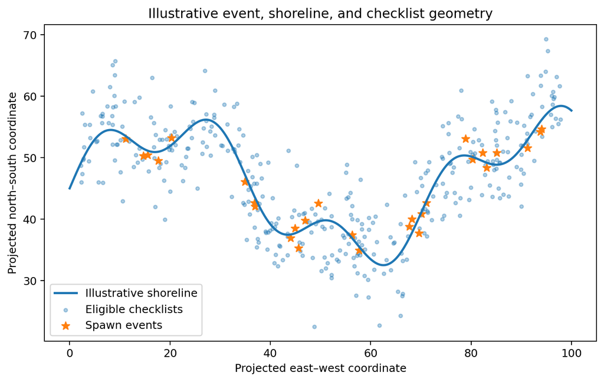

Illustrative Figure 3. The support map should display checklists, shoreline, herring records, event complexes, and spatial-precision diagnostics. Exact restricted coordinates must never appear in tracked public artifacts.

## Scientific questions and estimands

**Lay summary**“Do birds respond to spawn?” is too vague. A bird can respond by appearing more often, gathering in larger flocks, moving closer, leaving other places, arriving earlier, or joining a mixed-species feeding group. Each requires a different measurement.

| ID | Theme | Plain question | Estimand | Boundary |
| --- | --- | --- | --- | --- |
| Q1 | Local abundance | Are more birds reported near active spawn? | Expected reported count difference/ratio near spawn | Counts may change even when encounter does not |
| Q2 | Occurrence | Are focal species more likely to be detected? | Encounter probability difference | Not abundance; affected by detectability |
| Q3 | Timing | When does response start, peak, and end? | Event-time trajectory | Recorded spawn date is uncertain |
| Q4 | Distance | How far does the response extend? | Ring contrasts and distance-decay curve | Checklist and event point precision limit fine scales |
| Q5 | Redistribution | Do increases near spawn coincide with decreases elsewhere? | Near/far allocation and mass balance | No-recorded-spawn is not verified absence |
| Q6 | Dose | Do larger or longer spawn events generate stronger responses? | Intensity/extent modifier | Relative index and missing components |
| Q7 | Guild/community | Does the assemblage reorganize? | Guild count, richness, diversity, composition | Dominant species and observer effects |
| Q8 | Co-occurrence | Do species appear together more during spawn? | Null-adjusted and residual association change | Same checklist does not prove direct interaction or shared travel |
| Q9 | Phenology | Do birds track the moving spawn pulse? | Latitude–timing correspondence | Migration and calendar season are entangled |
| Q10 | Observation process | Do birders change where/how they sample? | Checklist/observer allocation | Must be reported beside biological results |

### Master analysis-module registry

Use the search box to filter the 50 planned modules. Priority labels distinguish core inference, supporting analyses, exploratory analyses, diagnostics, validation, and synthesis.

| ID | Priority | Analysis | Outcome | Technical plan | Lay summary |
| --- | --- | --- | --- | --- | --- |
| A01 | core | Sampling and metadata atlas | checklist/event metadata | Map effort, dates, protocols, observers, localities, sections, event quality, and missingness before looking at bird effects. | Shows where the data are strong enough to answer questions and where they are not. |
| A02 | core | Count-quality audit | numeric, X, lower-bound, heaped, extreme counts | Quantify count availability, rounding/heaping, duplicated shared-checklist disagreements, and upper-tail influence by species and guild. | Checks whether a reported flock of 500 can be compared fairly with a report of X or 5. |
| A03 | core | Exposure support atlas | event day × distance × region × year | Count independent events, checklists, observers, and localities in every proposed time-distance cell before modelling. | Prevents fitting impressive-looking curves where almost no data exist. |
| B01 | core | Species encounter model | detection/non-detection | Binomial GAMM/GLMM with event time, distance, effort, observer, locality, year, and calendar controls. | Asks whether a species is more likely to appear on a complete checklist near spawn. |
| B02 | core | Species hurdle model | detection + positive reported count | Two-part model: probability of detection and flock size conditional on a numeric report. | Separates ‘does it show up?’ from ‘how many are there when it does?’ |
| B03 | supporting | Zero-inclusive count model | reported count including zeros | Negative-binomial, generalized Poisson, or Tweedie benchmark selected by simulation diagnostics. | Provides one overall count response while checking whether one distribution can handle many zeros and huge flocks. |
| B04 | supporting | Ordinal flock-size model | 0, 1, 2–5, 6–20, 21–100, >100, X | Cumulative-link model robust to heaping and extreme numerical counts. | Tests whether large flocks become more common without pretending every count is exact. |
| B05 | exploratory | Upper-tail aggregation model | large-flock exceedance / extreme counts | Threshold exceedance, quantile, or generalized Pareto sensitivity for well-supported taxa. | Targets spectacular aggregations that ordinary averages can hide. |
| C01 | core | Guild hurdle models | guild detection and positive total count | Mechanistic guild totals with species contribution audits and leave-one-species-out checks. | Tests whether groups such as roe-diving ducks or gulls respond even when individual species are noisy. |
| C02 | core | Total herring-associated bird count | sum of supported reported counts | Tweedie/NB/hurdle model with dominant-species decomposition. | Asks the broad question: are more herring-associated birds recorded near spawning events? |
| C03 | core | Guild/species richness | number of detected taxa | Poisson/NB or occupancy-adjusted richness with effort controls. | Tests whether spawn attracts a more diverse bird assemblage, not only more individuals. |
| C04 | supporting | Diversity and evenness | Hill numbers / Shannon / Simpson | Checklist-level and event-area diversity with sample-size and effort standardization. | Distinguishes a genuinely diverse gathering from one giant flock of a single species. |
| D01 | core | Categorical event study | pre, spawn, egg, post periods | Non-overlapping event-time bins with simultaneous calendar controls and event-cluster uncertainty. | Shows when the response begins, peaks, and fades. |
| D02 | core | Continuous event-time trajectory | smooth response over days from spawn | Restricted low-rank smooth or distributed-lag model inside supported periods. | Avoids forcing the biological response into one arbitrary two-week box. |
| D03 | supporting | Timing uncertainty model | start/end/midpoint/interval-jittered event dates | Repeated imputation or latent date interval sensitivity. | Acknowledges that the recorded date may not be the exact day birds first respond. |
| E01 | core | Concentric distance-ring model | 0–1, 1–2, 2–3, 3–4, 4–5, 5–10, 10–20 km | Ring-specific event-time effects with support and spatial-precision checks. | Directly answers how close birds need to be to spawn for the signal to appear. |
| E02 | core | Continuous distance-decay model | smooth or monotone distance response | Log-distance smooth or monotonic effect, with protocol-specific spatial precision. | Estimates how rapidly the response weakens with distance rather than choosing only one radius. |
| E03 | core | Time × distance response surface | 2-D event-day/distance surface | Tensor-product GAM or spatial-temporal field restricted to well-supported cells. | Shows whether the response is brief and very local, or broader and longer-lasting. |
| E04 | supporting | Cumulative multi-event exposure | weighted exposure to all concurrent events | Distance-decay kernels summed over overlapping events, with alternative bandwidths. | Handles coastlines where birds may be responding to several nearby spawns at once. |
| E05 | supporting | Spawn-footprint sensitivity | point, length-based shoreline segment, event complex | Compare point distance with conservative extent buffers and shoreline-linked exposure. | Checks whether a long spawn was wrongly represented by one point. |
| F01 | core | Regional allocation model | share of birds in near, middle, and far zones | Multinomial or Dirichlet-multinomial model conditional on the regional observed total. | Tests whether birds are redistributed toward spawn even when total regional numbers stay similar. |
| F02 | core | Near–far–total mass balance | near count, far count, regional total | Joint or stacked models with common event-day risk sets. | Separates local concentration from a broader regional influx. |
| F03 | core | Repeated-locality panel | same locality across exposed and unexposed dates/years | Locality fixed effects, year/calendar controls, and event clustering. | Compares a place with itself, reducing bias from some sites always having more birds. |
| F04 | core | Same-observer matched analysis | same observer across roles/periods | Observer-stratified conditional models or fixed effects. | Reduces differences caused by some birders being more skilled or more likely to visit spawn. |
| F05 | supporting | Stacked difference-in-differences | active vs comparison location changes | Event-specific risk sets with pre-trend checks and event-cluster bootstrap. | Asks whether active shorelines changed more than similar shorelines on the same dates. |
| F06 | exploratory | Synthetic-control event studies | dense sites with donor pools | Weighted donor locations or matrix-completion methods for very well-observed events. | Builds a custom ‘what would have happened without spawn’ comparison for the best-monitored places. |
| G01 | core | Raw pairwise co-occurrence | same-checklist species pairs | Jaccard, phi, odds ratios, conditional detection, and count correlations by phase and distance. | Identifies which species tend to be reported together, while recognizing that one checklist is not proof of one mixed flock. |
| G02 | core | Null-adjusted co-occurrence | observed minus expected pair association | Permutation/null models preserving species prevalence, checklist richness, location, date, and effort strata. | Checks whether species occur together more often than expected just because both are common. |
| G03 | core | Detection JSDM/GLLVM | multispecies detection matrix | Species-specific herring/effort effects plus multiple latent factors and residual association matrices. | Separates shared responses to spawn and habitat from leftover species associations. |
| G04 | supporting | Abundance JSDM | multispecies reported-count matrix | Count-capable latent-variable model for a reduced, well-supported species set. | Tests whether flock sizes of different species rise and fall together after adjustment. |
| G05 | core | Phase- and distance-specific association networks | change in residual association | Compare pre, active, egg, and post networks and inner/outer distance zones. | Tests whether mixed-species gatherings become more tightly connected during spawn. |
| G06 | supporting | Community composition model | species-by-checklist composition | GLLVM plus constrained ordination/PERMANOVA as a transparent benchmark. | Asks whether the whole bird community changes, even when total bird numbers do not. |
| H01 | core | Spawn intensity components | Surface, Macrocystis, Understory, length, width | Component-specific modifiers with missingness indicators and method interactions. | Tests whether stronger or more extensive spawn records draw larger responses without treating missing measurements as zero. |
| H02 | supporting | Latent/measurement-error intensity | uncertain underlying spawn magnitude | Bayesian measurement model or multiple-indicator latent score. | Combines imperfect herring measures while keeping their uncertainty visible. |
| H03 | supporting | Source event vs event complex | alternative event definitions | Repeat core models using source rows and adjacency-based event complexes. | Checks whether one biological spawn was split into several database records. |
| I01 | supporting | Phenological ‘silver wave’ | latitude × event date × bird response | Spatiotemporal GAM/hierarchical migration model. | Tests whether mobile birds track the northward progression of spawning. |
| I02 | exploratory | Interannual and lagged response | annual bird metrics vs current/lagged spawn | Region-year time-series model with effort standardization and autocorrelation. | Looks for broader food-web effects that persist beyond the immediate event. |
| I03 | exploratory | Age/sex and behaviour-code response | demographic/behaviour subsets | Descriptive and hierarchical models only where reporting is sufficiently complete. | Explores whether particular age groups or feeding behaviours are especially associated with spawn. |
| J01 | core diagnostic | Birder visitation model | checklists, unique observers, observer continuity | Event-area submission allocation and repeated-observer choice models. | Measures whether birders—not only birds—shift toward active spawn. |
| J02 | diagnostic | Count reporting model | numeric vs X/unquantified | Model count availability among detections by exposure, observer, species, and flock size proxies. | Checks whether big spawn flocks are more likely to be reported as X instead of a number. |
| J03 | diagnostic | Checklist richness/detection process | all-bird checklist richness | Model whether conspicuous aggregations change search duration, reporting completeness, or detection of unrelated taxa. | Checks whether seeing a huge flock makes observers notice or report more species overall. |
| J04 | exploratory diagnostic | Comment/behaviour text audit | local-only keyword flags | Privacy-safe local text mining for spawn, roe, feeding, and mixed-flock terms; no public quotes or identifiers. | Uses observers’ notes only as supporting evidence and never exposes personal or exact-location information. |
| K01 | diagnostic | False-date placebos | shifted event dates | Repeat core contrasts at ±14, ±28, and matched random dates. | A true spawn signal should weaken when the event date is deliberately wrong. |
| K02 | diagnostic | False-location placebos | shifted or nonspawn shorelines | Geographically plausible placebo exposures and no-recorded-spawn years. | A true spatial signal should be stronger at real spawn shorelines than at fake ones. |
| K03 | diagnostic | Falsification taxa | species without a verified mechanism | Separate habitat-matched falsification models; never force a triple difference without exchangeability. | Checks for broad seasonal artifacts, while admitting that no control species is perfect. |
| K04 | validation | Blocked prediction and stability | held-out events, years, regions, localities | Leave-event/year/region-out validation, spatial blocks, influence deletion, and posterior predictive checks. | Tests whether conclusions survive new places and years rather than only fitting the data already seen. |
| K05 | validation | Prospective holdout | future eBird releases and new spawn events | Freeze the model now and evaluate later data without changing it. | Provides the strongest future confirmation because Version 2 is designed after seeing Version 1 results. |
| L01 | synthesis | Species-to-guild hierarchy | species-specific effect estimates | Second-stage multivariate meta-analysis with traits and cross-species covariance. | Summarizes the average guild response without hiding species that behave differently. |
| L02 | synthesis | Region meta-analysis | region-specific effects | Hierarchical partial pooling or multivariate meta-analysis across stock regions. | Shows whether the relationship is general or mainly a Strait of Georgia phenomenon. |
| L03 | synthesis | Evidence triangulation dashboard | all compatible estimands | Direction, magnitude, uncertainty, predictive performance, and placebo evidence summarized without averaging incompatible outcomes. | Combines many analyses into one transparent conclusion instead of selecting the most favourable model. |

## Analytical dataset construction

**Lay summary**Before modelling, every bird checklist must be linked to relevant herring events in both time and space. We will preserve uncertainty instead of forcing every checklist to one event and one exact distance.

### Checklist grain

- Collapse shared checklists to one independent birding event while retaining a private source crosswalk.
- Use complete stationary and travelling checklists under configurable effort filters; retain excluded rows with reasons.
- Zero-fill approved species on complete checklists; do not treat non-detection as confirmed ecological absence.
- Preserve numeric, X, lower-bound, ambiguous, and missing count states.
- Create strictly prior observer experience and locality accessibility covariates without using future or focal-outcome information.

### Event grain

- Retain immutable source records and construct alternative event complexes from spatial-temporal adjacency.
- Assign event-quality tiers rather than excluding all imperfect records from every analysis.
- Represent start/end uncertainty using alternative dates or interval-aware exposure.
- Use point, conservative length/width footprint, shoreline-linked, and event-complex geometries as measurement sensitivities.

### Risk sets and independence

- Construct event-day-distance cells from all plausible concurrent events; never duplicate a checklist across events and then treat rows as independent.
- For regional comparisons, define same-calendar candidate areas and explicit contamination rules.
- Use herring event as the primary uncertainty cluster, with location, observer, year, and region as additional dependence structures.

## Counts, occurrence, flock size, and upper tails

**Lay summary**A species may already be common before spawn, so it may not appear on more checklists even if thousands more birds arrive. We will therefore separate the chance of seeing the species from the number reported when it is seen.

| Family | Response | Strength | Main limitation | Role |
| --- | --- | --- | --- | --- |
| Encounter GAMM/GLMM | 0/1 detection | Robust zero-filling; interpretable probability | Misses flock-size changes | Core companion |
| Hurdle model | Detection + positive count | Matches two biological processes | Conditional count component is not total abundance | Co-primary |
| NB/Tweedie count | Zero-inclusive count | Single overall relative-count effect | Can fit poorly with heaping/extremes | Benchmark/supporting |
| Ordinal flock model | Count bins + X | Robust to imprecision and huge counts | Less direct count scale | Supporting |
| GAM time-distance surface | Detection or count | Flexible timing and distance | Needs dense support; concurvity risk | Core if support passes |
| Fixed-effects panel/DiD | Location/event contrasts | Controls time-invariant site differences | Parallel-trend/common-support assumptions | Core triangulation |
| Allocation/mass balance | Zone shares and totals | Directly targets redistribution | Requires common event-day risk sets | Co-primary |
| JSDM/GLLVM | Multispecies matrix | Community response and residual association | Residual correlation is not proof of interaction | Core community module |
| Second-stage hierarchy | Species/region effect estimates | Partial pooling without forcing shared nuisance structure | Depends on compatible first-stage estimands | Synthesis |

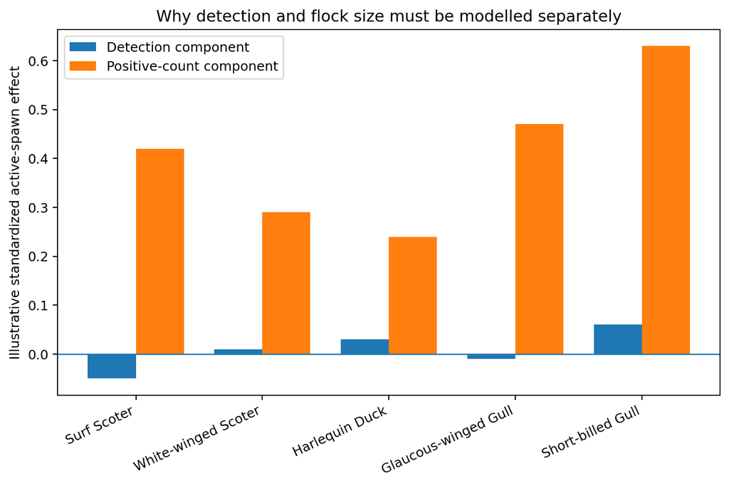

Illustrative Figure 4. A plausible pattern is weak encounter change but strong positive-count change. The two hurdle components answer different biological questions and must not be collapsed in interpretation.

**Primary count-family decision gate**

For each supported species/guild, benchmark hurdle NB/lognormal, zero-inclusive NB, generalized Poisson, Tweedie, ordinal, and robust positive-count alternatives using simulation-based calibration, zero structure, dispersion, heaping, tail influence, and held-out predictive loss. The family decision is made by a prespecified rule and logged before interpreting the herring term.

**Extreme flock counts**

Never delete a large count solely because it is large. Audit source count type, duplicates, taxonomic aggregation, observer, event, and comments locally; report influence; run top-1%, winsorized, ordinal, robust, and threshold-exceedance sensitivities. Public artifacts contain aggregate influence ranks, not checklist IDs or exact coordinates.

## Event timing, distance decay, and exposure surfaces

**Lay summary**The effect may peak for only a few days and within only a few kilometres. Testing a single 5 km, two-week box can miss that shape. Version 2 will estimate the shape directly.

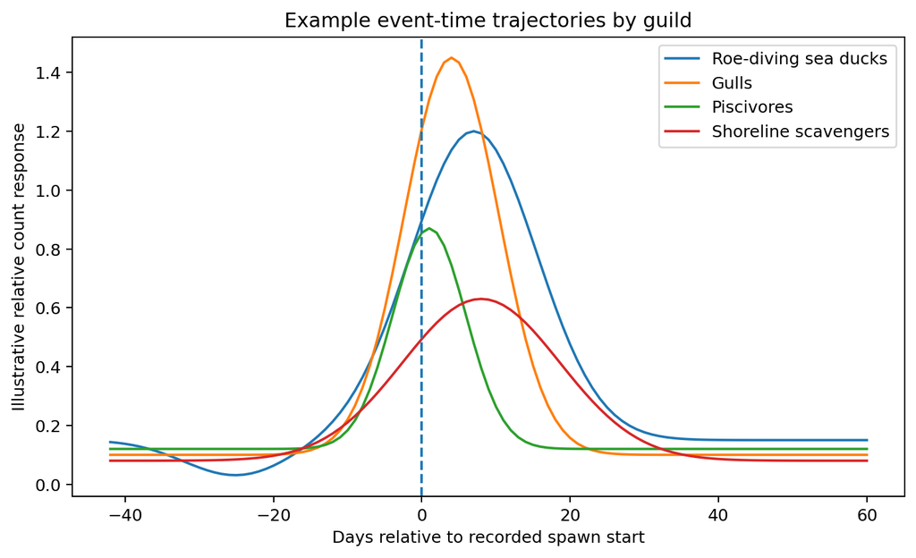

Illustrative Figure 5. Mechanistic guilds can peak at different times: piscivores around adult spawning, gulls near surface/intertidal availability, and roe-diving ducks through the egg period.

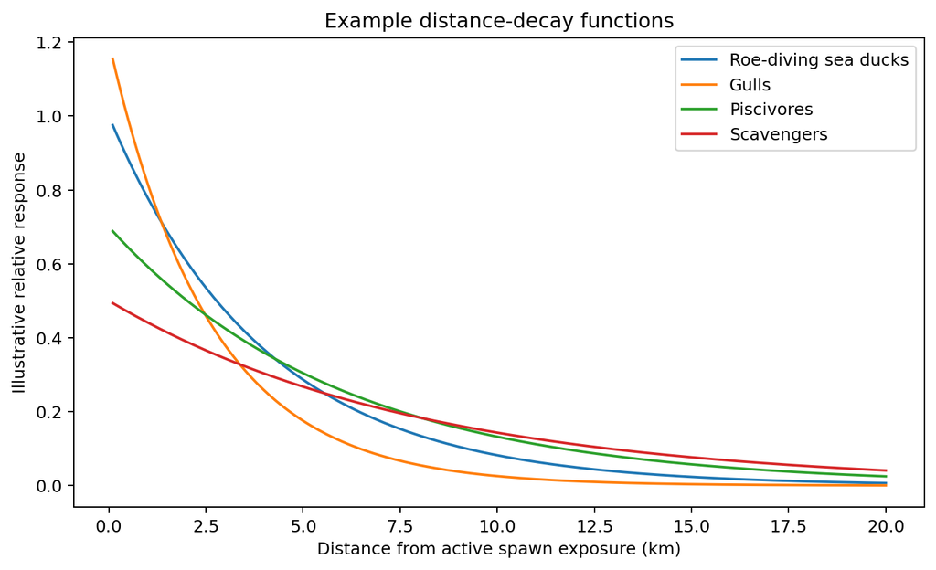

Illustrative Figure 6. Distance rings provide transparent contrasts; continuous curves estimate the decay shape. Both should be reported.

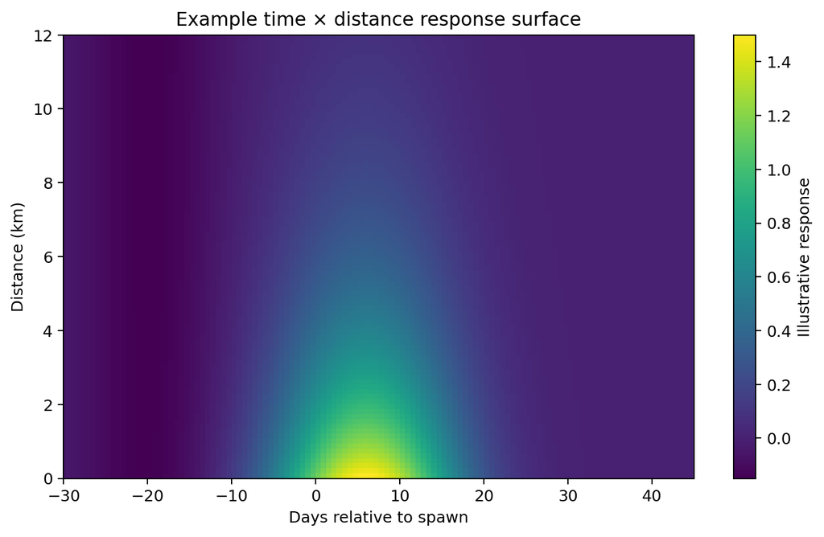

Illustrative Figure 7. A supported time-distance surface can reveal a brief local pulse, a delayed egg response, or a broad regional pattern. Unsupported cells remain blank in the empirical version.

| Dimension | Prespecified alternatives | Purpose |
| --- | --- | --- |
| Spatial buffer/rings | 0.5, 1, 2, 3, 4, 5, 10, 20 km | Discrete rings plus continuous decay; protocol-specific precision |
| Temporal bins | −42:−29, −28:−15, −14:−1, 0:2, 3:7, 8:14, 15:28, 29:60 | Non-overlapping event study plus smooth trajectory |
| Event date | start, end fallback, midpoint, full interval, jittered | Represent timing uncertainty instead of one fixed date |
| Event geometry | source point, length-based shoreline extent, event complex | Quantify point-geometry misclassification |
| Event quality | strict, moderate, inclusive tiers | Do not discard every imperfect record from every model |
| Checklist effort | strict, primary, broader | Duration, travel distance, speed if derivable, observers, protocol |
| Checklist type | stationary only; stationary + short travel; broader travel | Assess spatial precision and habitat mixing |
| Observer design | random effect, prior expertise, same observer, observer fixed effect | Quantify observer heterogeneity |
| Location design | same locality, shoreline segment, event area, region | Test sensitivity to spatial unit |
| Count treatment | numeric only, X as ordinal, top 1% exclusion, winsorized, robust tail | Preserve rather than invent counts |
| Taxonomy | named species lower bound, ambiguous guild upper bound, forms/hybrids audit | Bracket taxonomic uncertainty |
| Study period | 1988–2025, 2000–2025, 2010–2025, 2015–2025 | Balance historical coverage against sample size |
| Region | Strait of Georgia and all supportable stock regions | Estimate heterogeneity and transportability |

## Redistribution: more near spawn and fewer elsewhere

**Lay summary**We will not assume that an increase near spawn means more birds entered the whole region. The same birds may have moved from other shorelines. Near, far, and total counts will be examined together.

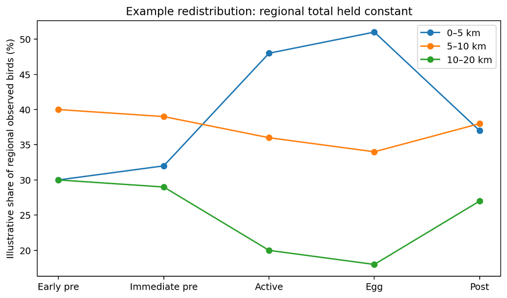

Illustrative Figure 8. In this example, the regional total is stable but the share within 5 km rises while the outer share falls—evidence consistent with redistribution.

### Allocation conditional on regional total

Multinomial/Dirichlet-multinomial zone counts, conditioning on the observed total for the event-day-region. This directly estimates where observed birds are allocated.

**Lay:** Of all birds recorded in the region that day, what share was near spawn?

### Near–far–total mass balance

Joint models for near count, far count, and total count distinguish concentration from regional influx.

**Lay:** Did nearby numbers rise because distant numbers fell, or because the whole region gained birds?

### Repeated-locality panel

Location fixed effects compare the same locality across event phases and nonspawn years/dates.

**Lay:** Did this same place change when spawn occurred?

### Same-observer design

Observer fixed/stratified models reduce skill and preference differences.

**Lay:** When the same person surveys both situations, do they report more birds near spawn?

## Guilds, richness, diversity, and community composition

**Lay summary**Species that feed in similar ways may respond together. We will group birds by mechanism, but we will also keep species-specific results so one abundant species cannot silently determine the whole guild result.

| priority_tier | Guild | Tier A | Tier B | Tier C | Falsification | Total candidates |
| --- | --- | --- | --- | --- | --- | --- |
|  | active_spawn_piscivores | 0 | 8 | 8 | 0 | 16 |
|  | alcid_piscivores | 0 | 0 | 4 | 0 | 4 |
|  | falsification_panel | 0 | 0 | 0 | 2 | 2 |
|  | gull_roe_scavengers | 2 | 4 | 3 | 0 | 9 |
|  | intertidal_roe_foragers | 0 | 0 | 7 | 0 | 7 |
|  | roe_diving_seaducks | 3 | 6 | 1 | 0 | 10 |
|  | shoreline_scavengers_raptors | 0 | 1 | 4 | 0 | 5 |
|  | surface_vegetation_roe | 0 | 1 | 4 | 0 | 5 |

Current scaffold counts are provisional because the 58-candidate registry and the 47-row legacy-derived support registry still need canonical reconciliation.

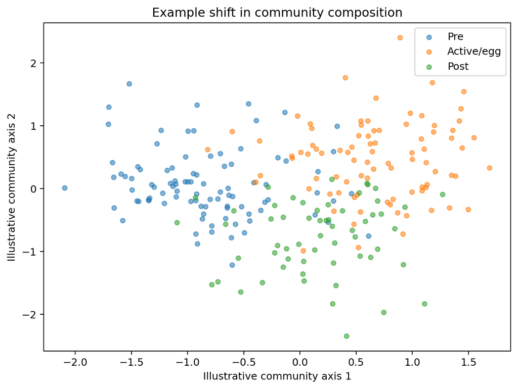

Illustrative Figure 9. Community models can detect a shift in species composition even if total bird numbers change little.

### Guild dominance safeguards

- Report each species’ contribution to guild count and guild effect.
- Repeat guild models leave-one-species-out and with capped influence weights.
- Report total count, richness, Hill diversity, and composition separately.
- Use ambiguous taxa as lower/upper guild bounds only when all possible identities belong to the same guild.

## Co-occurrence, shared travel, and mixed-species aggregation

**Lay summary**Bird species may gather or travel together, but two species appearing on the same checklist does not prove they were in one flock. We will first remove the effects of season, habitat, effort, observer, and herring exposure, then ask whether species still occur together more strongly during spawn.

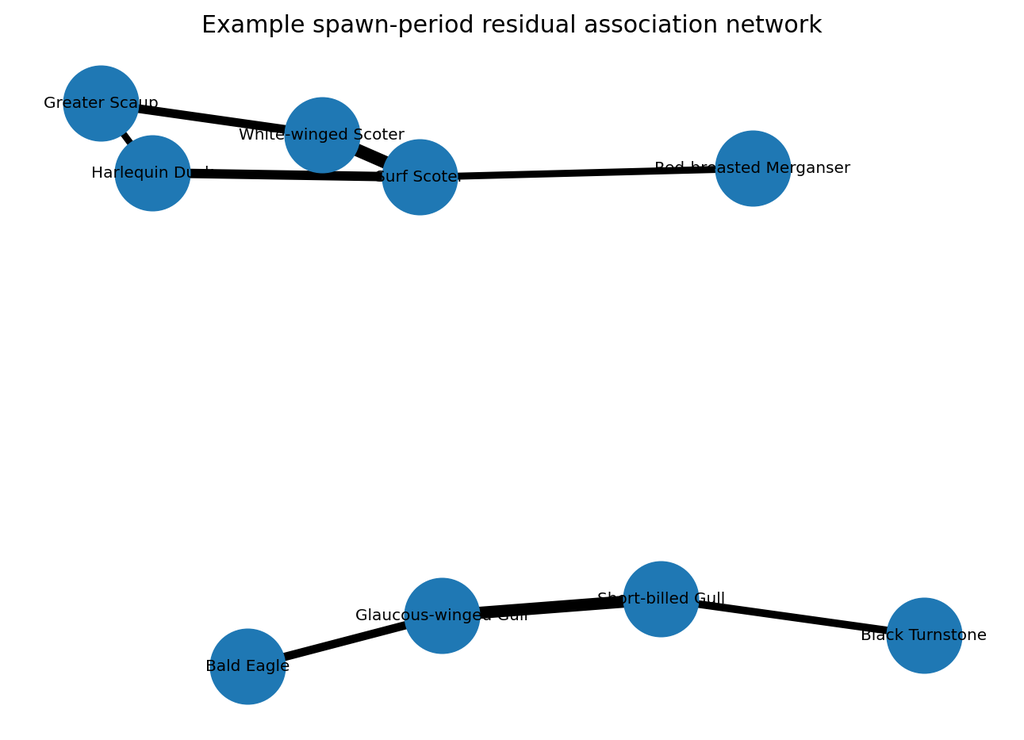

Illustrative Figure 10. A residual association network after adjustment. Edge thickness represents conditional association, not proven direct interaction.

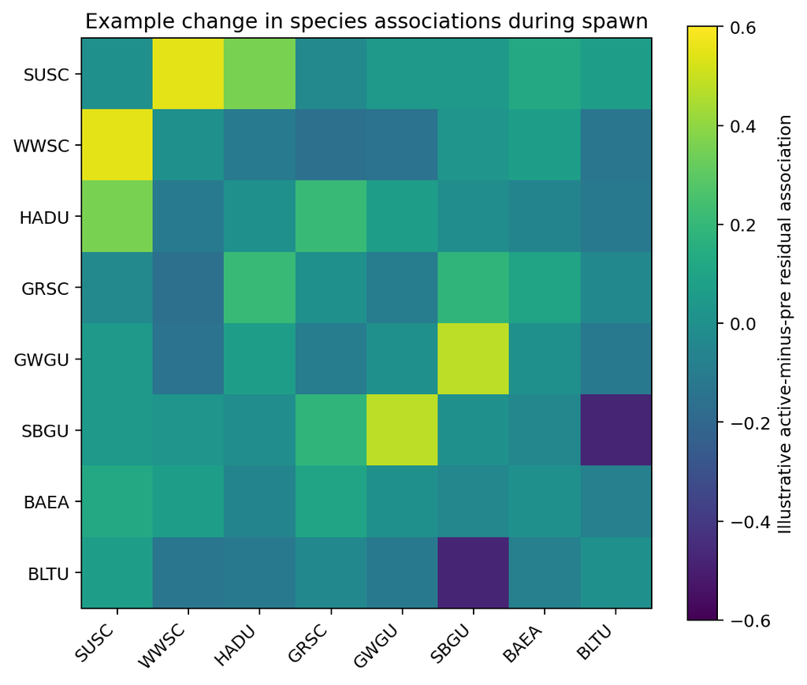

Illustrative Figure 11. Active-minus-pre association changes identify pairs that become more or less tightly associated during the resource pulse.

### Required co-occurrence layers

1. **Raw:** Jaccard similarity, phi correlation, odds ratios, conditional detection, count correlation.
2. **Null-adjusted:** permutations preserving prevalence, richness, observer/effort, location, and calendar strata.
3. **Environment-adjusted:** JSDM/GLLVM with species-specific fixed and random effects plus multiple latent factors.
4. **Context-specific:** separate or varying association matrices by phase, distance zone, region, and event size.
5. **Network summaries:** density, modularity, centrality, guild mixing, and leave-event/year-out stability.

**Prohibited shortcut**Do not place contemporaneous “number of other birds” into each species’ primary model as an ordinary predictor. It is itself an outcome of herring exposure and can create mathematical coupling, mediation bias, or collider bias. Joint models and leave-one-species-out community metrics are the primary approaches.

## Herring magnitude, extent, event complexes, and measurement uncertainty

**Lay summary**The herring data do not measure one perfect quantity called “biomass.” Different survey components and event dimensions have missing values and different meanings. Version 2 will test them separately before attempting any combined index.

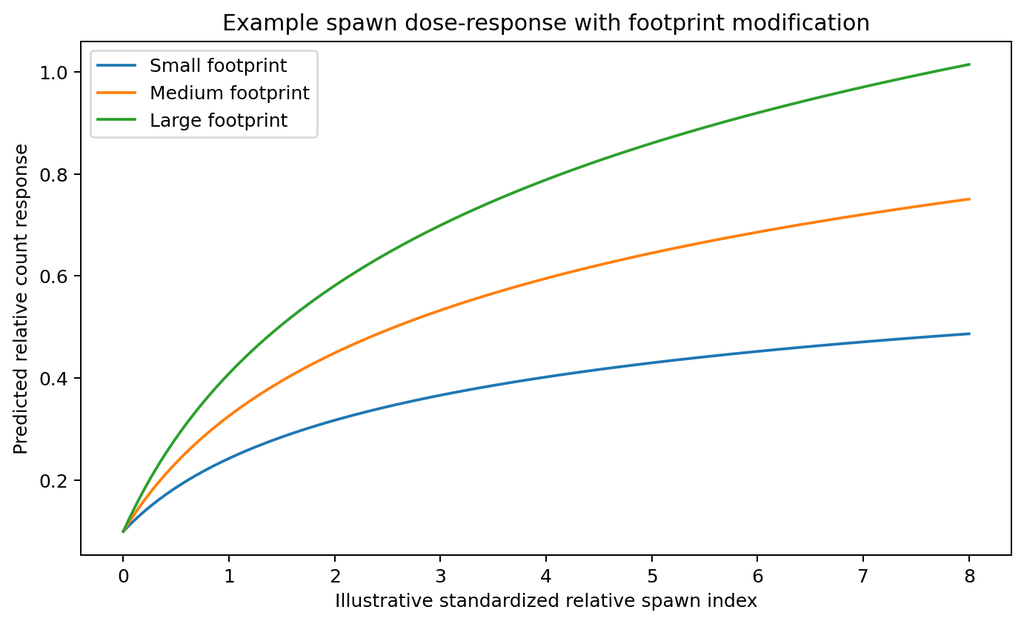

Illustrative Figure 12. Response may depend on both relative spawn index and the spatial footprint of the event.

### Herring exposure hierarchy

#### Binary/event phase

Any recorded active event under an explicit spatial and temporal definition.

#### Extent

Length, width, conservative footprint area, exposed shoreline length, event-complex extent.

#### Component indices

Surface, Macrocystis, Understory analyzed separately with availability patterns.

#### Composite relative index

Sum of observed components, never replacing missing components with zero.

#### Measurement model

Optional latent score/measurement-error model for comparable records.

#### Method and era

Survey method, component completeness, satellite-era and COVID-era sensitivities.

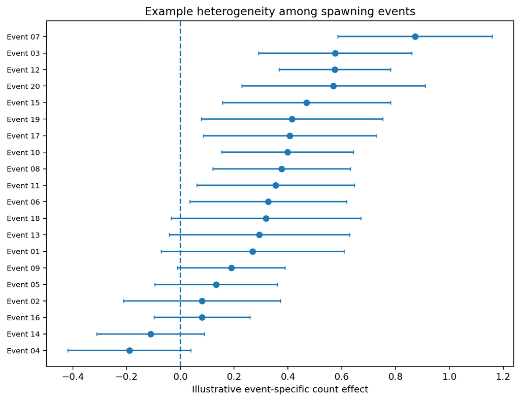

Illustrative Figure 13. Event-specific effects reveal whether the overall pattern is broad or driven by a few exceptional spawning events.

## Phenological tracking and longer-term effects

**Lay summary**Some birds may follow spawning northward, and strong spawn years may affect birds beyond the immediate two-week event. These questions are separate from local aggregation and need their own models.

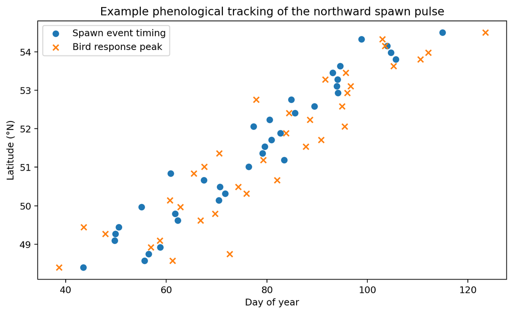

Illustrative Figure 14. The ‘silver wave’ model compares the latitudinal timing of spawn with the timing of bird response.

### Phenological model components

- Latitude, region, event date, and species/guild-specific migration timing.
- Within-year progression distinguished from ordinary day-of-year seasonality.
- Peak response timing, event visitation probability, and count concentration.
- Current-year and lagged region-year spawn indices for broader carry-over hypotheses.

## Observation process: birders, effort, reporting, and detectability

**Lay summary**News of a spectacular spawn can attract birders as well as birds. We will measure changes in checklist volume, unique observers, observer turnover, effort, and count reporting so that this bias is visible rather than hidden inside the bird model.

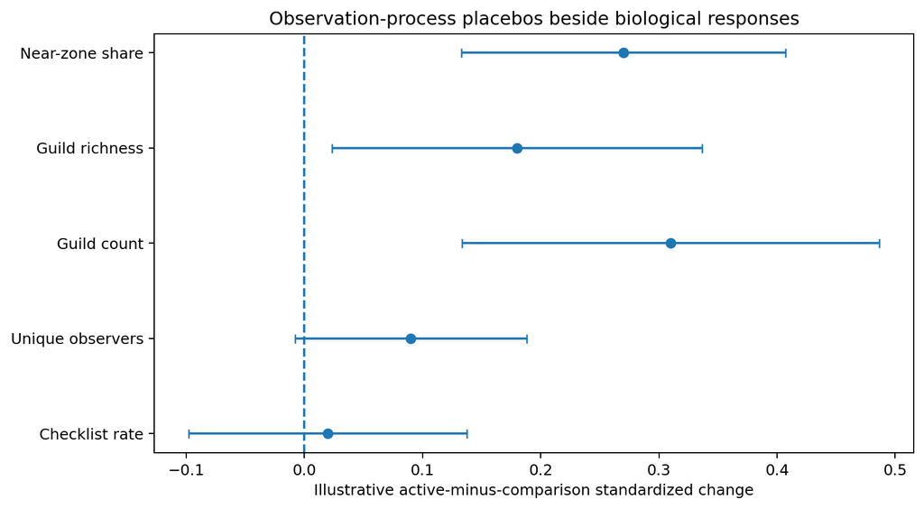

Illustrative Figure 15. Observer-placebo effects should be displayed beside biological effects. A biological response that greatly exceeds the visitation shift is more convincing than one that mirrors it exactly.

### Observation-process outcomes

- Checklist submissions and unique observers per event-area-day.
- Observer retention and Jaccard overlap between pre and active periods.
- Same-observer choice among supported shoreline alternatives.
- Duration, travel distance, observer number, start time, and locality/hotspot composition.
- Numeric versus X count reporting among detections.
- All-bird checklist richness and unrelated-species falsification patterns.
- Local-only privacy-safe comment/behaviour keyword audit, with no public text excerpts.

## Validation, sensitivity, falsification, and multiplicity

**Lay summary**A result is useful only if it survives reasonable changes in radius, timing, data quality, observer treatment, and model family—and if similar effects do not appear at fake dates or fake places.

| Gate | Diagnostic | When | Decision rule |
| --- | --- | --- | --- |
| Input integrity | SHA-256, header, schema, shapefile-bundle checks | Before processing | Stop on mismatch |
| Join/cardinality | many-to-one and one-row-per-unit assertions | Every join | Stop on loss/inflation |
| Support | events, years, observers, localities, ring-day cells | Before fitting each module | Do not estimate unsupported cells |
| Model diagnostics | simulation residuals, dispersion, zero structure, convergence, identifiability | Every fit | Change family only by registered rule |
| Influence | large flocks, events, observers, localities, years | Core models | Report material shifts |
| Spatial/temporal validation | held-out events, spatial blocks, years, regions | Core models | Report calibration and loss |
| Placebos | false dates, locations, nonspawn years | Core conclusions | Weaken claims if similar effects persist |
| Observation process | checklist and unique-observer allocation | Beside biological models | Do not hide preferential visitation |
| Prospective confirmation | future release/new events | After model freeze | No redesign after seeing holdout |

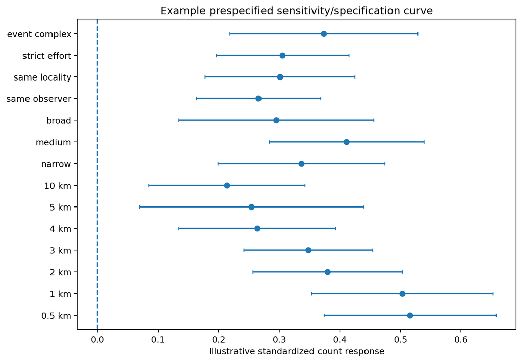

Illustrative Figure 16. A specification curve displays every prespecified compatible estimate. It prevents selective reporting of the most favourable radius or time window.

### Multiplicity strategy

- Define a small core family of primary count, allocation, timing, distance, guild, and observation-process estimands.
- Use hierarchical shrinkage and/or false-discovery control within clearly defined species/guild families.
- Do not treat every sensitivity row as an independent discovery test.
- Report effect sizes and intervals for all registered core models, including null and opposite-direction results.
- Use model stacking or evidence synthesis only for compatible predictive targets; do not average incompatible estimands.

## Cross-model evidence synthesis

**Lay summary**The final conclusion will be strongest when several independent clues agree: larger flocks near spawn, a clear distance and timing pattern, lower bird share farther away, stronger guild/community aggregation, and weak effects at fake dates and places.

| Observed pattern | Interpretation |
| --- | --- |
| Encounter ↑; positive count ↑; near share ↑; far share ↓; total stable | Strongest pattern for local redistribution toward spawn |
| Encounter unchanged; positive count ↑ | Flock aggregation without more occupied checklists |
| Near count ↑; far count stable; total ↑ | Regional influx, availability shift, or observation-process change |
| Near and far change similarly | Regional seasonality/migration more plausible than local spawn concentration |
| Biological response and observer visitation both ↑ | Ecological signal may exist, but preferential visitation contributes |
| Co-occurrence ↑ before adjustment only | Shared prevalence/habitat/effort explains the pair |
| Residual association ↑ after herring/environment adjustment | Conditional species association; not proof of direct facilitation |
| Effect only in one radius/window/model | Fragile result; report as exploratory |
| Effect repeats across counts, allocation, guilds, and placebos fail | Convergent evidence supporting a herring-associated response |

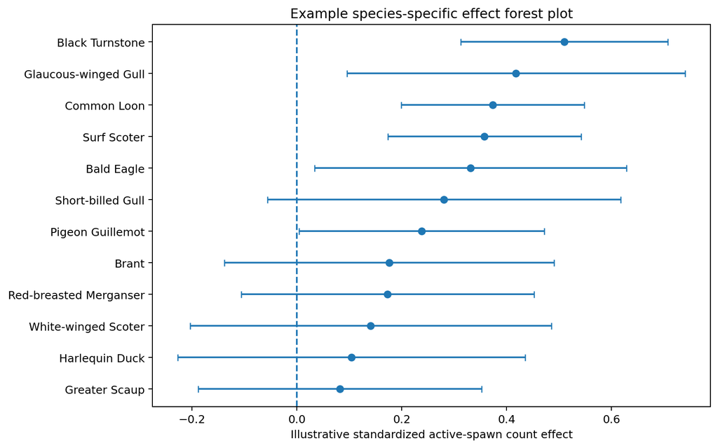

Illustrative Figure 17. Species estimates remain visible before guild-level synthesis. Partial pooling should reduce noise without forcing all species to share one response.

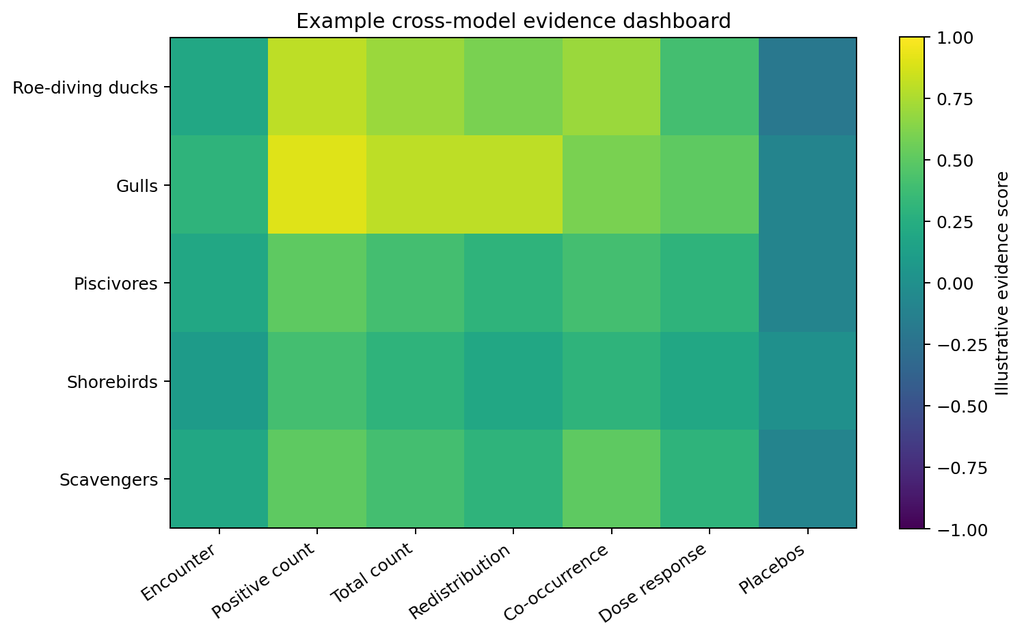

Illustrative Figure 18. A final dashboard summarizes evidence by guild and estimand. Placebo evidence is shown as a penalty/caution rather than hidden.

### Strong

Coherent event-time and distance pattern, positive reported-count or allocation effect, stable across events/years, and weak placebos.

### Moderate

Directionally consistent across several models but uncertain magnitude or some visitation/seasonality ambiguity.

### Suggestive

Biologically plausible signal in one or two estimands but limited support or sensitivity.

### Inconclusive

Intervals are wide, results disagree, or data support is inadequate.

### Contrary

Stable negative or opposite-direction response; interpreted scientifically rather than discarded.

### Not estimable

Insufficient independent events, overlap, temporal crossing, or count quality.

## Planned figures, tables, and reader-facing products

**Lay summary**Every technical result will be paired with a plain-language explanation of what was measured, what changed, and what the result cannot prove.

| Figure | Title | Purpose | Format | Planned location |
| --- | --- | --- | --- | --- |
| F1 | Coverage through time | Effort and event imbalance | Annual indexed lines | Metadata/coverage chapter |
| F2 | Spatial support map | Where checklists and spawn overlap | Map with shoreline/events/checklists | Methods and support |
| F3 | Guild event-time curves | Timing of biological response | Predicted curves with uncertainty | Core results |
| F4 | Hurdle decomposition | Detection vs flock-size response | Paired component effects | Core results |
| F5 | Distance decay | Spatial reach | Guild/species curves | Core results |
| F6 | Time-distance surface | Joint space-time pattern | Heatmap | Core/appendix |
| F7 | Redistribution mass balance | Near/far/total allocation | Zone share trajectories | Core results |
| F8 | Spawn dose response | Response vs relative index/extent | Marginal curves | Mechanistic results |
| F9 | Species forest plot | Species heterogeneity | Effect + interval | Core/synthesis |
| F10 | Co-occurrence network | Mixed-species association | Null-adjusted network | Community results |
| F11 | Association-change heatmap | Which pairs strengthen during spawn | Residual correlation difference | Community results |
| F12 | Observer placebo | Bird vs birder response | Parallel effect plot | Bias/validation |
| F13 | Specification curve | Robustness across choices | Prespecified estimates | Validation |
| F14 | Silver wave | Latitudinal tracking | Date vs latitude | Phenology |
| F15 | Community ordination | Assemblage reorganization | Latent/ordination scores | Community results |
| F16 | Evidence dashboard | Cross-model synthesis | Guild × estimand heatmap | Conclusion |
| F17 | Event heterogeneity | Which events drive response | Event forest plot | Heterogeneity |
| F18 | Count tail | Long-tailed flock counts | Percentile curve | Data audit |

### Required tables

**T1.** Input versions, checksums, licences, and metadata discrepancies.

**T2.** Checklist filtering and exclusion accounting.

**T3.** Herring event quality, component completeness, and geometry/date uncertainty.

**T4.** Species/guild taxonomy and support eligibility.

**T5.** Event-day-distance support and effective independent sample sizes.

**T6.** Core model specifications, estimands, and interpretation boundaries.

**T7.** Species and guild effect estimates on probability and count scales.

**T8.** Redistribution near/far/total contrasts.

**T9.** Co-occurrence and JSDM association summaries.

**T10.** Observer-visitation and count-reporting diagnostics.

**T11.** Sensitivity/specification matrix and robustness grades.

**T12.** Placebo, falsification, and held-out validation results.

**T13.** Region and event heterogeneity.

**T14.** Cross-model evidence statements, claim strength, and prohibited interpretations.

| ID | Priority | Family | Level | Response | Question | Candidate engine |
| --- | --- | --- | --- | --- | --- | --- |
| M01 | core | guild hurdle GAMM | guild | detection + positive reported count | Do guilds aggregate near spawn through time? | mgcv + glmmTMB |
| M02 | core | species hurdle GAMM | species | detection + positive reported count | Which species drive guild responses? | glmmTMB or brms |
| M03 | core | total herring-associated count | community | summed reported count | Does the total number of associated birds increase? | glmmTMB |
| M04 | core | guild richness model | community | number of detected guild species | Does assemblage richness increase? | glmmTMB |
| M05 | core | distance-ring event study | guild/species | count and detection | At what radius is the response strongest? | fixest/glmmTMB |
| M06 | core | distance × event-time surface | guild/species | count and detection | What is the continuous spatiotemporal response surface? | mgcv::bam or sdmTMB |
| M07 | core | regional allocation model | guild/species | zone count share | Do birds move from comparison zones toward spawn zones? | brms/cmdstanr |
| M08 | core | near-far mass-balance model | guild/species | expected count by near/far/region | Is local increase redistribution or regional influx? | glmmTMB/brms |
| M09 | core | repeated-location fixed-effects panel | guild/species | count and detection | Does the same eBird locality change in spawn vs nonspawn years/dates? | fixest |
| M10 | core | same-observer matched model | guild/species | count and detection | Does a repeated observer record more birds at spawn-exposed sites? | survival::clogit / fixest |
| M11 | supporting | encounter GAMM | species/guild | detection | Does probability of any report change? | mgcv |
| M12 | supporting | positive-count lognormal model | species/guild | log1p positive numeric count | Does flock size increase when present? | glmmTMB/mgcv |
| M13 | supporting | full count NB/Tweedie model | species/guild | zero-inclusive numeric count | Can one distribution capture occurrence and flock size? | glmmTMB |
| M14 | supporting | ordinal flock-size model | species/guild | 0,1,2-5,6-20,21-100,>100,X | Are large flocks more likely near spawn? | ordinal/brms |
| M15 | supporting | event-complex sensitivity | all | same as core outcomes | Does source-record fragmentation dilute effects? | same engines as core |
| M16 | supporting | spawn-footprint distance sensitivity | all | same as core outcomes | Does point geometry misclassify long spawns? | mgcv/glmmTMB |
| M17 | supporting | multi-event exposure kernel | all | count and detection | How does exposure to all concurrent events combine? | mgcv/brms |
| M18 | supporting | intensity dose-response | species/guild | count and detection | Do stronger spawn records generate larger responses? | mgcv/brms |
| M19 | supporting | component-quality intensity model | species/guild | count and detection | Can survey components/method be combined without treating missing as zero? | brms/cmdstanr |
| M20 | supporting | trait-based second-stage hierarchy | species | first-stage effect estimates | Do mechanisms explain species heterogeneity? | brms |
| M21 | exploratory | GLLVM community model | community | species detection/count matrix | Does community composition reorganize? | gllvm |
| M22 | exploratory | partial ordination/PERMANOVA | community | transformed count composition | Is multivariate composition associated with spawn exposure? | vegan |
| M23 | exploratory | silver-wave phenology model | species/guild | count/detection or peak timing | Do birds track latitudinal spawn progression? | mgcv/brms |
| M24 | supporting | stacked difference-in-differences event study | species/guild | count/detection | Do active locations change more than simultaneous comparison locations? | fixest |
| M25 | exploratory | generalized synthetic control | species/guild | aggregated count/detection rate | Can well-observed spawn sites be compared with weighted donor sites? | gsynth/fect |
| M26 | diagnostic | birder visitation process | observation process | checklists and unique observers | Does sampling shift toward active spawn? | glmmTMB/fixest |
| M27 | diagnostic | placebo dates | all | core outcomes | Are similar effects found at false dates? | same engines |
| M28 | diagnostic | placebo shoreline locations | all | core outcomes | Are effects specific to spawn locations? | same engines |
| M29 | diagnostic | same-location nonspawn-year control | all | core outcomes | Does the site show the pattern in years without recorded spawn? | fixest |
| M30 | supporting | coastwide region meta-analysis | species/guild | regional model effects | Are results consistent across stock regions? | metafor/brms |
| M31 | validation | prospective holdout | all | core outcomes | Do frozen models predict future events/years? | same engines |
| M32 | diagnostic | count-missingness model | species/guild | numeric vs X/unquantified among detections | Is count availability exposure-dependent? | glmmTMB |
| M33 | supporting | ambiguous-guild interval count | guild | lower/upper guild count bounds | Do guild results survive taxonomic ambiguity? | same engines as M01/M03 |

### Current candidate species examples

| Species | Guild | Tier | Evidence | Expected peak | Directional prior |
| --- | --- | --- | --- | --- | --- |
| Surf Scoter | roe_diving_seaducks | A | direct local evidence | spawn through eggs | positive local count; redistribution possible |
| White-winged Scoter | roe_diving_seaducks | A | direct local evidence | spawn through eggs | positive local count; redistribution possible |
| Harlequin Duck | roe_diving_seaducks | A | direct local evidence | spawn through eggs | positive local count |
| Glaucous-winged Gull | gull_roe_scavengers | A | direct regional mechanism | spawn through eggs | positive local count |
| Short-billed Gull | gull_roe_scavengers | A | direct regional mechanism | spawn through eggs | positive local count |
| Greater Scaup | roe_diving_seaducks | B | direct/observational | spawn through eggs | positive |
| Brant | surface_vegetation_roe | B | direct local assemblage evidence | spawn through eggs | positive but migration-confounded |
| Long-tailed Duck | roe_diving_seaducks | B | shared mechanism | spawn through eggs | positive |
| Black Scoter | roe_diving_seaducks | B | direct elsewhere/shared mechanism | spawn through eggs | positive |
| Barrow's Goldeneye | roe_diving_seaducks | B | diet/shared mechanism | spawn through eggs | positive |
| Common Goldeneye | roe_diving_seaducks | B | diet/shared mechanism | spawn through eggs | weak positive |
| Bufflehead | roe_diving_seaducks | B | shared mechanism | spawn through eggs | positive |
| Lesser Scaup | roe_diving_seaducks | C | shared mechanism/taxonomic ambiguity | spawn through eggs | exploratory positive |
| Common Merganser | active_spawn_piscivores | B | diet/plausible | active spawn | positive |
| Red-breasted Merganser | active_spawn_piscivores | B | diet/plausible | active spawn | positive |
| Common Loon | active_spawn_piscivores | B | association/plausible | active spawn | weak positive |
| Pacific Loon | active_spawn_piscivores | C | shared mechanism | active spawn | exploratory positive |
| Red-throated Loon | active_spawn_piscivores | C | shared mechanism | active spawn | exploratory positive |
| Western Grebe | active_spawn_piscivores | B | association | active spawn | heterogeneous |
| Horned Grebe | active_spawn_piscivores | B | plausible/direct observations | active spawn | positive |
| Red-necked Grebe | active_spawn_piscivores | B | plausible | active spawn | positive |
| Pelagic Cormorant | active_spawn_piscivores | B | observational | active spawn | positive |
| Brandt's Cormorant | active_spawn_piscivores | C | evidence outside pilot | active spawn | exploratory positive |
| Double-crested Cormorant | active_spawn_piscivores | B | plausible | active spawn | positive or null |
| Bald Eagle | shoreline_scavengers_raptors | B | observational mechanism | active through post | positive |
| Great Blue Heron | shoreline_scavengers_raptors | C | plausible shoreline predation | active through post | exploratory positive |
| American Crow | shoreline_scavengers_raptors | C | plausible scavenging | active through post | exploratory positive |
| California Gull | gull_roe_scavengers | B | diet/plausible | spawn through eggs | positive |
| American Herring Gull | gull_roe_scavengers | B | diet/taxonomy limited | spawn through eggs | positive |
| Western Gull | gull_roe_scavengers | C | shared mechanism | spawn through eggs | positive |
| Iceland Gull | gull_roe_scavengers | C | shared mechanism/taxonomy | spawn through eggs | exploratory positive |
| Bonaparte's Gull | gull_roe_scavengers | B | shared mechanism | spawn through eggs | positive |
| Ring-billed Gull | gull_roe_scavengers | B | shared mechanism | spawn through eggs | positive |
| Surfbird | intertidal_roe_foragers | C | plausible intertidal mechanism | egg window | exploratory positive |
| Black Turnstone | intertidal_roe_foragers | C | plausible intertidal mechanism | egg window | exploratory positive |
| Canada Goose | surface_vegetation_roe | C | shared vegetation mechanism | egg window | exploratory positive |
| Mallard | surface_vegetation_roe | C | shared vegetation mechanism | egg window | exploratory positive |
| American Wigeon | surface_vegetation_roe | C | shared vegetation mechanism | egg window | exploratory positive |
| Northern Pintail | surface_vegetation_roe | C | shared vegetation mechanism | egg window | exploratory positive |
| Pigeon Guillemot | alcid_piscivores | C | plausible piscivore | active spawn | exploratory positive |
| Rhinoceros Auklet | alcid_piscivores | C | plausible piscivore | active spawn | exploratory positive |
| Common Murre | alcid_piscivores | C | plausible piscivore | active spawn | exploratory positive |
| Marbled Murrelet | alcid_piscivores | C | plausible piscivore | active spawn | exploratory positive |
| Gadwall | falsification_panel | F | no strong direct mechanism | same windows | no prespecified biological effect |
| Northern Shoveler | falsification_panel | F | no strong direct mechanism | same windows | no prespecified biological effect |
| Hooded Merganser | active_spawn_piscivores | C | candidate; existing high checklist support but weaker marine mechanism | active spawn | exploratory |
| Clark's Grebe | active_spawn_piscivores | C | candidate; sparse named-species support; pooled Aechmophorus sensitivity | active spawn | exploratory |
| Eared Grebe | active_spawn_piscivores | C | candidate shared mechanism | active spawn | exploratory |
| Black Oystercatcher | intertidal_roe_foragers | C | candidate intertidal mechanism | egg window | exploratory |
| Dunlin | intertidal_roe_foragers | C | candidate intertidal mechanism | egg window | exploratory |
| Sanderling | intertidal_roe_foragers | C | candidate intertidal mechanism | egg window | exploratory |
| Rock Sandpiper | intertidal_roe_foragers | C | candidate intertidal mechanism | egg window | exploratory |
| Black-bellied Plover | intertidal_roe_foragers | C | candidate intertidal mechanism | egg window | exploratory |
| Common Raven | shoreline_scavengers_raptors | C | candidate scavenger | active through post | exploratory |
| Osprey | shoreline_scavengers_raptors | C | candidate piscivorous raptor | active spawn | exploratory |
| Caspian Tern | active_spawn_piscivores | C | candidate piscivore | active spawn | exploratory |
| Common Tern | active_spawn_piscivores | C | candidate piscivore | active spawn | exploratory |
| Glaucous Gull | gull_roe_scavengers | C | candidate gull guild | spawn through eggs | exploratory |

## Execution roadmap and gates

**Lay summary**The project should proceed in stages. Each stage must prove that its data and assumptions are adequate before the next stage opens. This keeps the expanded analysis ambitious without becoming uncontrolled model fishing.

| Phase | Purpose | Deliverables | Gate |
| --- | --- | --- | --- |
| 0 | New-repository build and V1 asset port | Clean private repo, provenance manifest, privacy scan, canonical registries | No outcomes opened |
| 1 | Source metadata and taxonomy | Verified inputs, field maps, shared-checklist rules, species/guild crosswalk | Human metadata gate |
| 2 | Herring event and exposure engineering | Source events, event complexes, quality tiers, time/distance surfaces | Map and support gate |
| 3 | eBird processing and outcome construction | Eligible checklists, zero-fill, numeric/X/lower-bound counts, guild/community outcomes | Privacy and cardinality gate |
| 4 | Outcome-blind design/support | Risk sets, balance, observer visitation, event-day-distance support | Scientific design gate |
| 5 | Core models | Counts, encounter, event-time, distance, redistribution, guilds | Diagnostics and validation gate |
| 6 | Community/co-occurrence | JSDM/GLLVM, networks, richness/diversity/composition | No rank-one shared structure |
| 7 | Advanced and mechanistic extensions | Intensity, phenology, event complexes, upper tails, lagged effects | Support-dependent |
| 8 | Triangulation and reporting | Evidence dashboard, manuscript tables/figures, lay summaries, reproducibility package | All caveats visible |
| 9 | Prospective confirmation | Frozen predictions for future years/events | Independent holdout |

### Core acceptance thresholds to freeze before outcomes

- Minimum independent events, years, regions, observers, and localities for every model family.
- Minimum event-day-distance cell support and no unsupported extrapolation.
- Common support and balance thresholds for regional comparisons.
- Maximum event, observer, locality, and year concentration.
- Count-family diagnostics and extreme-count influence rules.
- JSDM convergence, effective sample size, posterior predictive, and residual-association stability gates.
- Privacy scan and restricted-field denylist before every commit and public render.

## Repository, provenance, privacy, and reproducibility

**Lay summary**The new repository will copy only reusable code, metadata, tests, and documentation from Version 1. It will not copy raw eBird data, fitted results, private identifiers, or the old Git history.

### Clean-repository rules

- New private repository with clean history; Version 1 is a read-only provenance source, not a parent branch.
- Every ported file listed in a machine-readable manifest with source commit, source path, destination path, modifications, and privacy review.
- Allowlisted extraction only; no wholesale copy of `data/`, `outputs/`, model objects, weights, rendered outcome reports, or V1 Git objects.
- Raw inputs configured through local environment variables and verified by checksums.
- No checklist IDs, source observer IDs, source locality IDs/names, exact checklist coordinates, comments, or row-level restricted derivatives in tracked files.
- Aggregate public outputs only, with reproducible code and source hashes.

```
source repo: JTDingwall/ebird_herring_analysis
source branch: main (resolve and pin current SHA during setup)
destination: JTDingwall/herring-x-ebird-version-2
visibility: private
primary language: R + targets + renv
public report: reports/comprehensive_analysis_plan.html
```

## Source basis

This blueprint integrates the uploaded review, the audited Version 1 repository, official eBird analytical guidance, and current community-model cautions. The central biological premise is that herring spawn is a short-lived spatial resource pulse capable of reorganizing predator distributions, while the central analytical premise is that eBird inference depends on complete checklists, explicit effort, shared-checklist handling, zero-filling, observer/process adjustment, and honest spatial precision.

1. *Integrating Bird Response Data with Pacific Herring Spawn Information*, uploaded 17-page review, especially pp. 1–6 and 13–16.
2. Version 1 repository: `JTDingwall/ebird_herring_analysis`, audited `main` state and its metadata, decision, validation, and redesign records.
3. Strimas-Mackey et al. *Best Practices for Using eBird Data*, Version 2.0; Johnston et al. 2021 analytical guidelines.
4. Vallé et al. 2024, species associations in joint species distribution models: residual associations may reflect missing variables and should not be equated automatically with biotic interactions.
5. Pacific herring ecological studies summarized in the uploaded review, including direct counts, telemetry, behaviour, and ‘silver wave’ evidence.

**Interpretation boundary**Version 2 is a post-result exploratory redesign because Version 1 outcomes have already been examined. The plan can generate strong convergent evidence, but prospective confirmation requires future data or an independently frozen external region.

Generated from versioned registries with fixed seed 1988. All plotted values are synthetic examples. Repository paths and row counts should be revalidated by Codex against the canonical setup commit.